# Intro To Python slides

[figure not shown]

```python
from IPython.display import Image
Image("../src/photos/python.png")
```

## Intro To Python: Part 0

There is an over arching philosophy that has probably kept the python community together through thick and thin

```python
import this
```

```
The Zen of Python, by Tim Peters

Beautiful is better than ugly.
Explicit is better than implicit.
Simple is better than complex.
Complex is better than complicated.
Flat is better than nested.
Sparse is better than dense.
Readability counts.
Special cases aren't special enough to break the rules.
Although practicality beats purity.
Errors should never pass silently.
Unless explicitly silenced.
In the face of ambiguity, refuse the temptation to guess.
There should be one-- and preferably only one --obvious way to do it.
Although that way may not be obvious at first unless you're Dutch.
Now is better than never.
Although never is often better than *right* now.
If the implementation is hard to explain, it's a bad idea.
If the implementation is easy to explain, it may be a good idea.
Namespaces are one honking great idea -- let's do more of those!
```

### Python Is What?

```
Python is an interpreted, interactive, object-oriented programming language that combines remarkable power with very clear  syntax.
```

```python
help(object)
```

```
Help on class object in module builtins:

class object
 |  The most base type
```

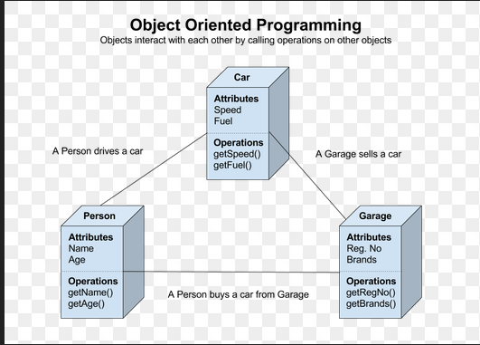

```python
Image("../src/photos/OOp.png")
```

### Object Oriented Programming

A coding paradigm in which Obejcts are the main abstraction and actions that occur on those objects of the data they contain are contained in methods.

`Class.method(data_to_act_on)` is the usual callling method

```python
help('class')
```

```
Class definitions
*****************

A class definition defines a class object (see section The standard
type hierarchy):

   classdef    ::= [decorators] "class" classname [inheritance] ":" suite
   inheritance ::= "(" [argument_list] ")"
   classname   ::= identifier

A class definition is an executable statement.  The inheritance list
usually gives a list of base classes (see Metaclasses for more
advanced uses), so each item in the list should evaluate to a class
object which allows subclassing.  Classes without an inheritance list
inherit, by default, from the base class "object"; hence,

   class Foo:
       pass

is equivalent to

   class Foo(object):
       pass

The class’s suite is then executed in a new execution frame (see
Naming and binding), using a newly created local namespace and the
original global namespace. (Usually, the suite contains mostly
function definitions.)  When the class’s suite finishes execution, its
execution frame is discarded but its local namespace is saved. [3] A
class object is then created using the inheritance list for the base
classes and the saved local namespace for the attribute dictionary.
The class name is bound to this class object in the original local
namespace.

The order in which attributes are defined in the class body is
preserved in the new class’s "__dict__".  Note that this is reliable
only right after the class is created and only for classes that were
defined using the definition syntax.

Class creation can be customized heavily using metaclasses.
```

[output cut: 22 more lines]

```
unexpected results.  Descriptors can be used to create instance
variables with different implementation details.

See also:

  **PEP 3115** - Metaclasses in Python 3000
     The proposal that changed the declaration of metaclasses to the
     current syntax, and the semantics for how classes with
     metaclasses are constructed.

  **PEP 3129** - Class Decorators
     The proposal that added class decorators.  Function and method
     decorators were introduced in **PEP 318**.

Related help topics: CLASSES, SPECIALMETHODS
```

[output not shown]

### Variables in Python

Variables tell the operating system to reserve some space for information to be stored, manipulated, and retreived later on.

They provide labels for your data, because computer programs are mostly read by humans and interpreted by compilers

You use the *assignment operator* `=`to declare a variable in python

```
number = 1
string = 'word'
decimal = 0.14
list = []
tuple = ()
key_value_pair = {'key': value}
set_of_something = {}
```

```python
number = 12
print(number ** 2)
```

```
144
```

## Functions: Built in and Defined:

The standard library in Python comes with a large amount of functions predefined for you to use, like the `help()` and `len()` functions.

```
def greet(name):
    print("Hello " + name)
```

### Basic Types Inside of Python

1. Numbers ( int and float )
2. Strings
3. Booleans
4. Lists
5. Tuples
6. Dictionarys
7. Sets

## Types

the `type()` function will let you peek inside the values type

#### Numbers

Ints and Floats

```python
numbers_and_stuff = 3.14
type(piece_of)
```

[output not shown]

```python
numbers_and_stuff + numbers_and_stuff
```

```
6.28
```

```python
print(3 // 14)
three, fourteen = str(numbers_and_stuff).split('.')
print(three, fourteen)
int(three) / int(fourteen)
```

```
0
3 14
```

```
0.21428571428571427
```

#### Strings

```python
type('hello')
```

```
str
```

```python
strings = " I've got no strings to hold me down "
print(len(strings))
strings[1:5]
```

```
37
```

```
"I've"
```

```python
strings[:7]
```

```
" I've g"
```

```python
strings[-14:]
```

```
' hold me down '
```

```python
strings.upper() * 5
```

```
" I'VE GOT NO STRINGS TO HOLD ME DOWN  I'VE GOT NO STRINGS TO HOLD ME DOWN  I'VE GOT NO STRINGS TO HOLD ME DOWN  I'VE GOT NO STRINGS TO HOLD ME DOWN  I'VE GOT NO STRINGS TO HOLD ME DOWN "
```

```python
shake_it_up = strings.swapcase().split("'")
shake_it_up * 2
```

```
[' i',
 'VE GOT NO STRINGS TO HOLD ME DOWN ',
 ' i',
 'VE GOT NO STRINGS TO HOLD ME DOWN ']
```

#### Booleans

Perfect for asking and checking for the state of things

```python
type(False)
```

```
bool
```

```python
one_fish = 1
two_fish = 2
one_fish < two_fish
```

```
True
```

```python
print(True + False)
```

```
1
```

```python
print(True + True)
```

```
2
```

## Null Values

What happens when I have nothing or nothing...yet `None`

```python
result = None
print(result)
```

```
None
```

```python
result is None
```

```
True
```

[figure not shown]

```python
Image("../src/photos/keep_calm_ask.png")
```

### Type Conversion

convert the values between different types

```python
#python supports multiple variable assignment as well
z = x = y = 1
print('x is ' + str(x), '\ny is ' + str(y), '\n \t \t z is ', str(z))
```

```
x is 1
y is 1
 	 	 z is  1
```

## Arithmetic Operators

| Symbol | Task |
| --- | --- |
| `+` | Addition |
| `-` | Subtraction |
| `/` | Division |
| `%` | Modulus |
| `*` | Multiplication |
| `//` | Floor Division |
| `**` | The the Power of |

```python
a_number = 100
another_number = 200

1 + 2 + 3 + 4 + 5 + a_number + another_number
```

```
315
```

### What's the Difference between `/` and `//`

Returning an integer vs. returning a float

```python
1 // 2
```

```
0
```

```python
1 / 2
```

```
0.5
```

#### :thinking_emoji: but what about??

```python
10 / 2.0
```

```
5.0
```

#### I made a float!!

```python
12.8 // 6.0
```

```
2.0
```

## Relational Operators

| Symbol | Description |
| --- | --- |
| `==` | True, if equal |
| `!=` | True, if not equal |
| `<` | less than |
| `>` | Greater than |
| `<=` | less than or equal to |
| `>=` | greater than or equal to |

```python
n = 1
```

```python
n == 1
```

```
True
```

```python
1 <= 1
```

```
True
```

```python
n != 1
```

```
False
```

n > 1

[figure not shown]

```python
Image("../src/photos/keep_calm_ask.png")
```

#### Logical Operators

- Combine two or more comparison operators

```python
(1 ==1) and (2 == 2)
```

```
True
```

```python
(1==2) and (2==2)
```

```
False
```

```python
(1==1) and (2!=1)
```

```
True
```

```python
(1 != 1) or (2 == 2) or (3 != 3) or (4 != 4)
```

```
True
```

```python
(1 == 1) & (2 == 2) & (3 == 3) & (4 != 4)
```

```
False
```

```python
(1 != 1) | (2 == 2) | (3 != 3) | (4 != 4)
```

```
True
```

## Bitwise Operators

[output not shown]

```python
a = 2 #10
b = 3 #11
print(a & b)
bin(a&b)
```

```
2
```

```
'0b10'
```

```python
5 >> 1
```

```
2
```

```python
5 << 1
```

```
10
```

[figure not shown]

```python
Image("../src/photos/question_kitteh.png")
```

## Lists

One of the workhorses of python's data types

- Lists allow you to push data into an ordered set of values
- Lists also let you access data by indexing

```python
l = ['apple', 'pear', 'peaches']
print(l)
```

```
['apple', 'pear', 'peaches']
```

## List Indexing

- Lists can be indexed using sqaure brackets to retrieve and element

```python
# you can access the indexed element of the list using bracket syntax
print(l[1])
```

```
pear
```

```python
# you can append to a list, making it mutable
l.append('nutella')
l
```

```
['apple', 'pear', 'peaches', 'nutella']
```

## List Slicing

- Lists can be indexed using sqaure brackets to retrieve a range of positions

```python
# you can combine data types inside of lists as wellb
combo_list = ['first', 'second', 'third', 9,8,7]
combo_list
```

```
['first', 'second', 'third', 9, 8, 7]
```

```python
combo_list[0:2]
```

```
['first', 'second']
```

```python
combo_list[:2]
```

```
['first', 'second']
```

```python
combo_list.append("appended")
combo_list.append("going to remove")
```

```python
combo_list
```

[output not shown]

```python
combo_list.remove("going to remove")
```

```python
combo_list[2:]
```

```
['third', 9, 8, 7, 'appended']
```

```python
combo_list.insert(1,"right after beginning")
combo_list
```

```
['first', 'right after beginning', 'second', 'third', 9, 8, 7, 'appended']
```

```python
nested_list = [combo_list,['inner','list']]
nested_list
```

[output not shown]

```python
nested_list[1][:]
```

```
['inner', 'list']
```

### State and Identity

- State is not identity
- Compare state with `==` compare identity with `is`
- Comparing *identity*, check for equality of reference
- Comparing *state*, check for equality of values

```python
X = [3,4]
Y = [3]
Y.append(4)
```

```python
X == Y
```

```
True
```

```python
X is Y
```

```
False
```

```python
Y.append(5)
print(X)
X = Y
X is Y
```

```
[3, 4]
```

```
True
```

## Variables are really References to a Value

references are distinct from the values they refer to variables are the *names* of reference

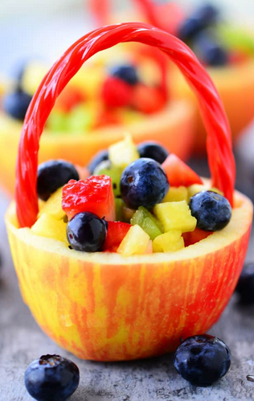

```python
Image("../src/photos/fruit_basket.png")
```

```python
fruit_basket = l
fruit_basket
```

```
['apple', 'pear', 'peaches', 'nutella']
```

### What happens when I change something in my basket?

```python
fruit_basket.append('grapes')
print(l)
```

```
['apple', 'pear', 'peaches', 'nutella', 'grapes']
```

## Collections:

Lists are examples of collections, they are a type, composed of other types

- `tuple` => `(val1,val2)`
- `set` => `{val1,val2}`
- `dict` => `{'key1': val1, 'key2': val2}`

### Tuples

- Tuples are immutable

```python
tup1 = (20, 'hi')
tup1
```

```
(20, 'hi')
```

```python
print("This is Totally going to print",tup1[1])
tup1[0] = 10
```

```
This is Totally going to print hi
```

```
---------------------------------------------------------------------------
TypeError                                 Traceback (most recent call last)
<ipython-input-76-d7531c95c794> in <module>()
      1 print("This is Totally going to print",tup1[1])
----> 2 tup1[0] = 10

TypeError: 'tuple' object does not support item assignment
```

```python
type(tup1)
```

```
tuple
```

### Dictionary

- A Dictionary is the Key-Value store in python
- Is is an unordered, changable, and indexed collection.

```python
dict1 = {'name': "Tom", "grade": 3.5}
dict1[0]
```

```
---------------------------------------------------------------------------
KeyError                                  Traceback (most recent call last)
<ipython-input-78-96ce6d9835b2> in <module>()
      1 dict1 = {'name': "Tom", "grade": 3.5}
----> 2 dict1[0]

KeyError: 0
```

```python
dict1['name']
```

```
'Tom'
```

```python
dict1_new = {"name" : ["Tom", "Sam", "Raj", "Jessica"], "grade" : [3.5, 2.4, 3.8]}
dict1_new['name']
```

```
['Tom', 'Sam', 'Raj', 'Jessica']
```

```python
dict1_new.keys()
```

```
dict_keys(['name', 'grade'])
```

```python
dict1_new.values()
```

```
dict_values([['Tom', 'Sam', 'Raj', 'Jessica'], [3.5, 2.4, 3.8]])
```

## Sets

- Lists might contain duplicate values, sets do not
- `set()` or declare it literally with `{ }`

```python
X = set([1,2,3,4])
X
```

```
{1, 2, 3, 4}
```

```python
next_set = {1988, 1999}
type(next_set)
```

```
set
```

```python
next_set.add(2010)
next_set
```

```
{1988, 1999, 2010}
```

## Conditionals and Control Flow

Indentation plays a significant role in Python's ability to understand whats nested inside of the Scope of another functions execution call.

- white space affects semantics of python code

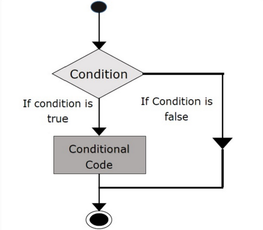

```python
Image("../src/photos/control_flow.png")
```

```python
help('if')
```

```
The "if" statement
******************

The "if" statement is used for conditional execution:

   if_stmt ::= "if" expression ":" suite
               ("elif" expression ":" suite)*
               ["else" ":" suite]

It selects exactly one of the suites by evaluating the expressions one
by one until one is found to be true (see section Boolean operations
for the definition of true and false); then that suite is executed
(and no other part of the "if" statement is executed or evaluated).
If all expressions are false, the suite of the "else" clause, if
present, is executed.

Related help topics: TRUTHVALUE
```

```python
x = 25
if x > 0:
    print('x is strictly positive')
    print(x)
print("I'm Done executing")
```

```
x is strictly positive
25
I'm Done executing
```

## Iteration

python's keyword `for` is used for iterating over collections

```python
for i in l:
    print(i)
```

```
apple
pear
peaches
nutella
grapes
```

```python
# This can get a little excessive if you leave your keyboard unlocked
for i in [0,1,3,4,5,6,7,8]:
    print("Coffee")
```

```
Coffee
Coffee
Coffee
Coffee
Coffee
Coffee
Coffee
Coffee
```

#### `while` loops

While loops will repeat an execution of a statement or group of statements until the condition is met.

```python
x = 0

while x < 5:
    print('x = ',x)
    print(' x is > 5, adding 1 to x')
    x+=1
```

[output not shown]

## Python's `range` function

you can pass a start,stop, and incrementor to the range function to generate a variable of a certain length or step.

```python
for i in range(5):
    print("Brew coffee")
```

```
Brew coffee
Brew coffee
Brew coffee
Brew coffee
Brew coffee
```

#### List Comprehension

These get fun

```python
name = "Tom Goodheart"
```

```python
empty_list = []
for i in name:
    empty_list.append(i)
```

```python
empty_list
```

```
['T', 'o', 'm', ' ', 'G', 'o', 'o', 'd', 'h', 'e', 'a', 'r', 't']
```

```python
empty_list = [i for i in name]
```

```python
empty_list
```

```
['T', 'o', 'm', ' ', 'G', 'o', 'o', 'd', 'h', 'e', 'a', 'r', 't']
```

```python
num_list = [1,2,3,4,5]
```

```python
num_list1 = []
for i in num_list:
    num_list1.append(i ** 2)
```

```python
num_list1
```

```
[1, 4, 9, 16, 25]
```

```python
num_list2 = [ i//2 for i in num_list1]
num_list2
```

```
[0, 2, 4, 8, 12]
```

```python
num_list_even = [ i for i in num_list if i % 2 == 0]
```

```python
num_list_even
```

```
[2, 4]
```

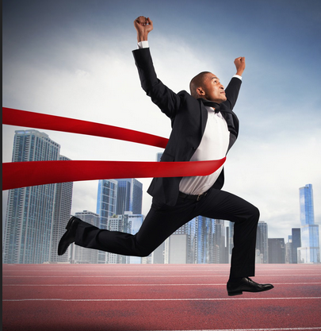

```python
Image("../src/photos/finish_line.png")
```